# Detecting Viral Sequences from Shotgun Metagenomes

Nick Waters

8/6/2018

# Intro

We were curious how prevalent viruses are in Anaerobic Digesters. Here is my non-rigourous attempt at getting some answers.

# The Data

I used MG-RAST webserver to select a subset of metagenomes. I searched for any terms containing “anaerobic digestion” and with “shotgun” in `seq_type`. this yielded 212 metagenomes. I downloaded the metadata, and manually created a file called `annotations.txt` that included just the mg-rast ID (which looks kinda like a checksum).

# Taxonomy

From there, I downloaded the summary statistics for the taxonomy using the (very fragile) `mg-display-statistics.py` script.

```bash
mkdir display_output
while read x;
do
  # its written in python2.  Its 2018, and its written in python2.
  `which python2` `which mg-display-statistics.py` --id $x --stat domain > display_output/${x}.txt ;
done < accessions.txt
```

Nest, I read in the files, made a combined table from all of them:

```r
dir <- "./display_output/"
files <- list.files(dir)
df <- data.frame("id"=NA, "level"=NA, "value"=NA )
df <- df[!is.na(df), ]
for (f in files){
  if (file.size(file.path(dir, f)) > 0){
     tmp <- read.csv(
       file.path(dir, f), sep="\t",
       header=F, col.names = c("level", "value"))
  # tmp <- rbind(tmp, data.frame(
  #   "level"="Total",
  #   "value"=sum(tmp$value)))
     tmp$id <- f
     df <- rbind(df, tmp)
  }
}
str(df)
```

```
## 'data.frame':    931 obs. of  3 variables:
##  $ level: Factor w/ 8 levels "Archaea","Bacteria",..: 2 1 3 4 2 3 1 2 3 1 ...
##  $ value: int  76001207 1594049 343215 29310 7385 160 134 3490 271 12 ...
##  $ id   : chr  "0013693d2c6d676d343731343433372e33.txt" "0013693d2c6d676d343731343433372e33.txt" "0013693d2c6d676d343731343433372e33.txt" "0013693d2c6d676d343731343433372e33.txt" ...
```

…adding columns with the mgrast id and for the fractional abundances. From this we get an average viral abundance:

```r
df <- df %>%
  group_by(id) %>%
  mutate(frac = value / sum(value)) %>%
  as_data_frame()
str(df)
```

```
## Classes 'tbl_df', 'tbl' and 'data.frame':    931 obs. of  4 variables:
##  $ level: Factor w/ 8 levels "Archaea","Bacteria",..: 2 1 3 4 2 3 1 2 3 1 ...
##  $ value: int  76001207 1594049 343215 29310 7385 160 134 3490 271 12 ...
##  $ id   : chr  "0013693d2c6d676d343731343433372e33.txt" "0013693d2c6d676d343731343433372e33.txt" "0013693d2c6d676d343731343433372e33.txt" "0013693d2c6d676d343731343433372e33.txt" ...
##  $ frac : num  0.974777 0.020445 0.004402 0.000376 0.961714 ...
```

```r
df <- as.data.frame(df)
str(df)
```

```
## 'data.frame':    931 obs. of  4 variables:
##  $ level: Factor w/ 8 levels "Archaea","Bacteria",..: 2 1 3 4 2 3 1 2 3 1 ...
##  $ value: int  76001207 1594049 343215 29310 7385 160 134 3490 271 12 ...
##  $ id   : chr  "0013693d2c6d676d343731343433372e33.txt" "0013693d2c6d676d343731343433372e33.txt" "0013693d2c6d676d343731343433372e33.txt" "0013693d2c6d676d343731343433372e33.txt" ...
##  $ frac : num  0.974777 0.020445 0.004402 0.000376 0.961714 ...
```

```r
average_viral_frac = mean(df[df$level=="Viruses", "frac"])
```

Our average abundance is 0.0011495.

Lastly, we plot the abundances on a log scale.

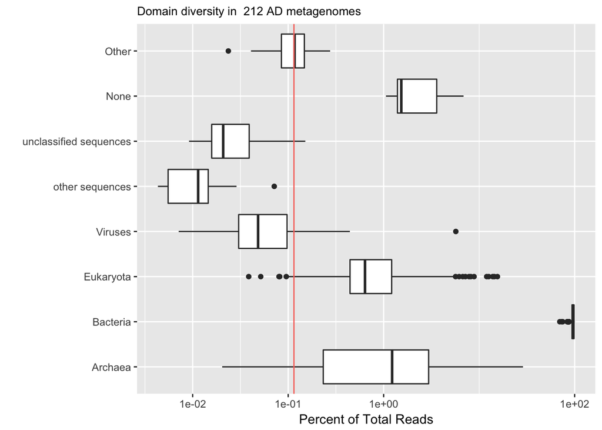

```r
ggplot(df, aes(x=level, y=frac * 100, group=level)) + geom_boxplot() + scale_y_log10(breaks=c( 0.001, .01, .1, 1, 100)) + coord_flip() +
  geom_hline(aes(yintercept=average_viral_frac * 100,
                 color = "green"))+
  scale_color_discrete(guide=F)+
  labs(subtitle = paste("Domain diversity in ",length(files), "AD metagenomes "),
       y="Percent of Total Reads",
       x = "")
```

# Rarefaction

we downloaded the data, again using the MG-RAST API.

```bash
mkdir rare_output;
while read x;
do
  wget -O rare_output/${x}.txt "http://api-ui.mg-rast.org/metagenome/${x}?verbosity=stats&detail=rarefaction"
done < accessions.txt
```

Each file is a list of values, so we do some data munging to read it in to something useful.

```r
target_coverage = 20

raredir <- "./rare_output/"
rarefiles <- list.files(raredir)
f <- rarefiles[1]


raredf <- data.frame("x"=NaN, "y"=NaN, "id"=NaN )
raredf <- raredf[!is.na(raredf), ]

for (f in rarefiles){
  x <- readLines(file.path(raredir, f))
  splits <- strsplit(x, "\\],\\[")[[1]]
  # clean up first and last items
  splits[1] <- substring(splits[1], first=3)
  splits[length(splits)] <- substring(splits[length(splits)], first=1, last=nchar(splits[length(splits)]) - 2)
  splitdf <- as.data.frame(splits) %>% separate(splits, into = paste("V", 1:2, sep = ","), sep = ",")
  colnames(splitdf) <- c("x", "y")
  splitdf$id <- f
  raredf <- rbind(raredf, splitdf)
}
str(raredf)
```

```
## 'data.frame':    224079 obs. of  3 variables:
##  $ x : chr  "0" "29628" "59256" "88884" ...
##  $ y : chr  "2.76496777340435" "1847.17397431562" "2063.7714352611" "2211.80358929291" ...
##  $ id: chr  "0013693d2c6d676d343731343433372e33.txt" "0013693d2c6d676d343731343433372e33.txt" "0013693d2c6d676d343731343433372e33.txt" "0013693d2c6d676d343731343433372e33.txt" ...
```

Lastly, we convert values to numeric, and draw a plot:

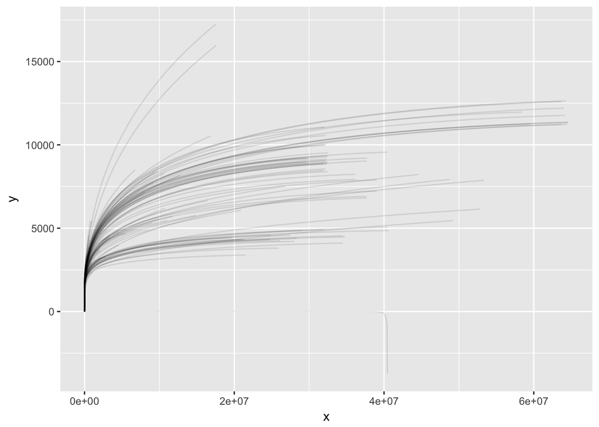

```r
raredf$x <- as.numeric(raredf$x)
raredf$y <- as.numeric(raredf$y)
ggplot(raredf, aes(x=x, y=y, group=id)) + geom_line(color="black", alpha=.1)
```